# Time Series: A First Course with Bootstrap Starter

# Lesson 9-7: Periodogram

- We further investigate the periodogram.
- It can be viewed as a crude estimator of the spectral density.

## Definition 9.7.2

- Given a sample of size $n$ from a time series $\{ X_t \}$, the centered DFT is
  $$\widehat{X} (\lambda) = n^{-1/2} \sum_{t=1}^n (X_t - \overline{X}) e^{-i
  \lambda t}$$
  for $\lambda \in [-\pi, \pi]$.
- So ${| \widehat{X} (\lambda) |}^2 = I(\lambda)$.

## Corollary 9.7.5

Suppose $\{ X_t \}$ is either $m$-dependent or is a linear time series with mean $\mu$ and causal moving average representation. If $\mu = 0$ then
$$\frac{ \widetilde{I} (\lambda) }{ f(\lambda) } \Rightarrow \begin{cases}
\chi^2_1 \quad \mbox{if} \; |\lambda| = 0, \pi \\ .5 \chi^2_2 \quad
\mbox{if} \; |\lambda| \in (0, \pi).
\end{cases}$$
If $\mu \neq 0$, we use the centered DFT and $I(\lambda)/f(\lambda)$ has the same limit if $\lambda \neq 0$.

## Remark 9.7.6. The Periodogram is Inconsistent

- Corollary 9.7.5 implies the periodogram is not consistent as an estimator of the spectral density.
- In contrast, Theorem 9.6.6 shows that weighted averages of the periodogram are consistent for spectral means.

## Fact 9.7.7. Independence of Periodogram Ordinates over Fourier Frequencies

- From Corollary 7.2.9, DFT ordinates are approximately uncorrelated.
- Because they are also asymptotically complex Gaussian (see book), the DFT ordinates are asymptotically independent.
- Hence $I(\lambda_j)$ is asymptotically independent of $I(\lambda_k)$ for $j \neq k$.

## Example 9.7.9. Periodogram of the Wolfer Sunspots

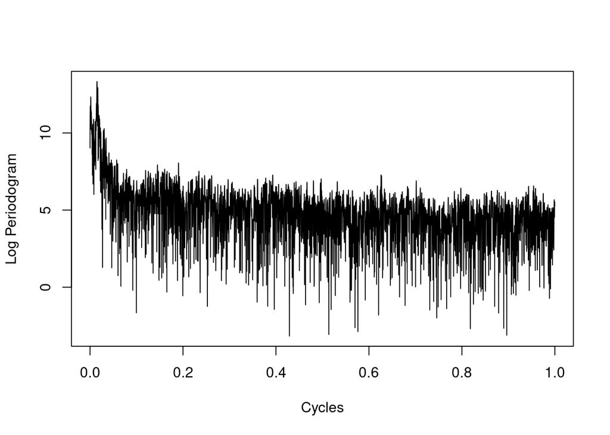

```r
wolfer <- read.table("wolfer.dat")
wolfer <- ts(wolfer[,1],start=1749,frequency=12)
data <- wolfer
n <- length(data)
acfs.sample <- NULL
mu.hat <- sum(data)/n
for(k in 0:(n-1))
{
    acf.sample <- sum((data[1:(n-k)]-mu.hat)*(data[(k+1):n]-mu.hat))/n
    acfs.sample <- c(acfs.sample,acf.sample)
}
grid <- 10000
lambda <- seq(0,grid)*pi/grid
pgram <- cos(0*lambda)*acfs.sample[1]
for(h in 1:(n-1))
{
    pgram <- pgram + 2*cos(h*lambda)*acfs.sample[h+1]
}
pgram <- ts(pgram[-1],start=0,frequency=grid)
plot(log(pgram),xlab="Cycles",ylab="Log Periodogram")
```

```r
print(pi*which.max(pgram)/grid)
```

```
## [1] 0.04712389
```